# Report: Wash data analysis

Steve and Jonathan

2020-03-09

## Service in the previous year computation

- To understand what data we’re losing in our gain-loss model, and think about whether we should consider imputing data for missing years, we want to know for each household how many surveys have data which can’t be used in the gain-loss model because the previous year is missing.
- The first observation for any household is used in the baseline model (and never has a previous year), so we don’t count these as missing.
- For example, in the Table below, household 1 had 3 consecutive interviews, so nprev_miss is 0. Household 3 had 11 interviews, but there is a gap after the first one, so nprev_miss is 1.

| hhid | year | watersource | watersourceP | n | nprev_miss1 | nprev_miss2 |
| --- | --- | --- | --- | --- | --- | --- |
| 1 | 11 | 1 |  | 3 | 1 | 0 |
| 1 | 12 | 1 | 1 | 3 | 1 | 0 |
| 1 | 13 | 1 | 1 | 3 | 1 | 0 |
| 3 | 1 | 1 |  | 11 | 2 | 1 |
| 3 | 4 | 1 |  | 11 | 2 | 1 |
| 3 | 5 | 1 | 1 | 11 | 2 | 1 |
| 3 | 6 | 1 | 1 | 11 | 2 | 1 |
| 3 | 7 | 1 | 1 | 11 | 2 | 1 |
| 3 | 8 | 1 | 1 | 11 | 2 | 1 |
| 3 | 9 | 1 | 1 | 11 | 2 | 1 |

[output cut: 4 more lines]

- We sum up the number of previous year missing interviews for each missing category. For example, in HH 1 there is 1 interview missing in the previous year, we sum up all interviews missing 1 interview in the previous and do the same for the rest of the categories ($2,3,4,...$), etc. The distribution of **total** number of interviews with missing immediate previous year are shown in the Figure below.
- Including the first year, 43% have missing previous interviews.
- The denominator for the percentages is the total number of all interviews, including year 1 (reason to aggregate by total number of interviews per category as opposed to frequency)

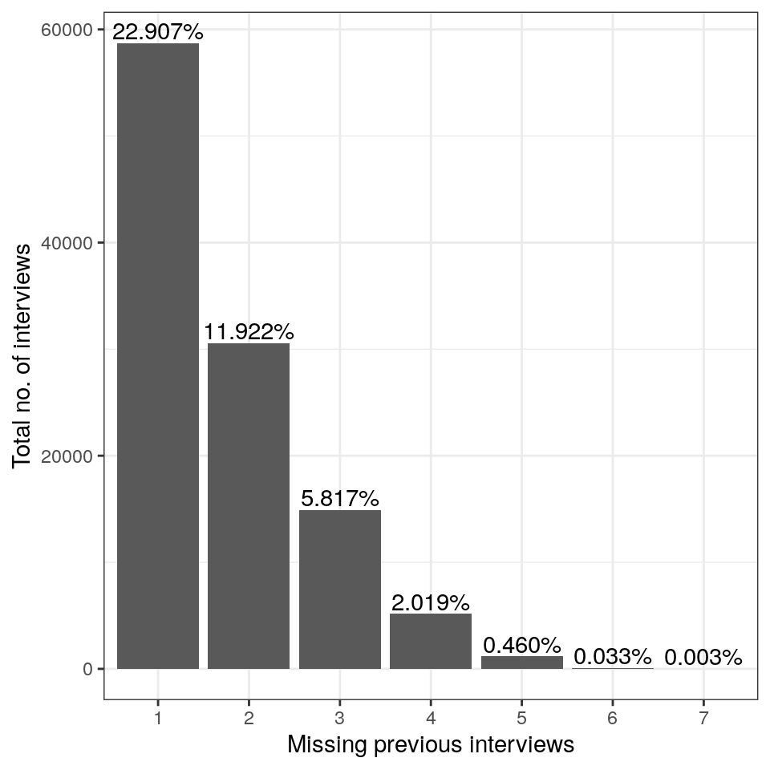

- Ignoring the first year interviews (31% which are modeled separately), the proportion of interviews we are actually dropping due to missing preceding year interviews are 17%(about 12% of all the interviews).

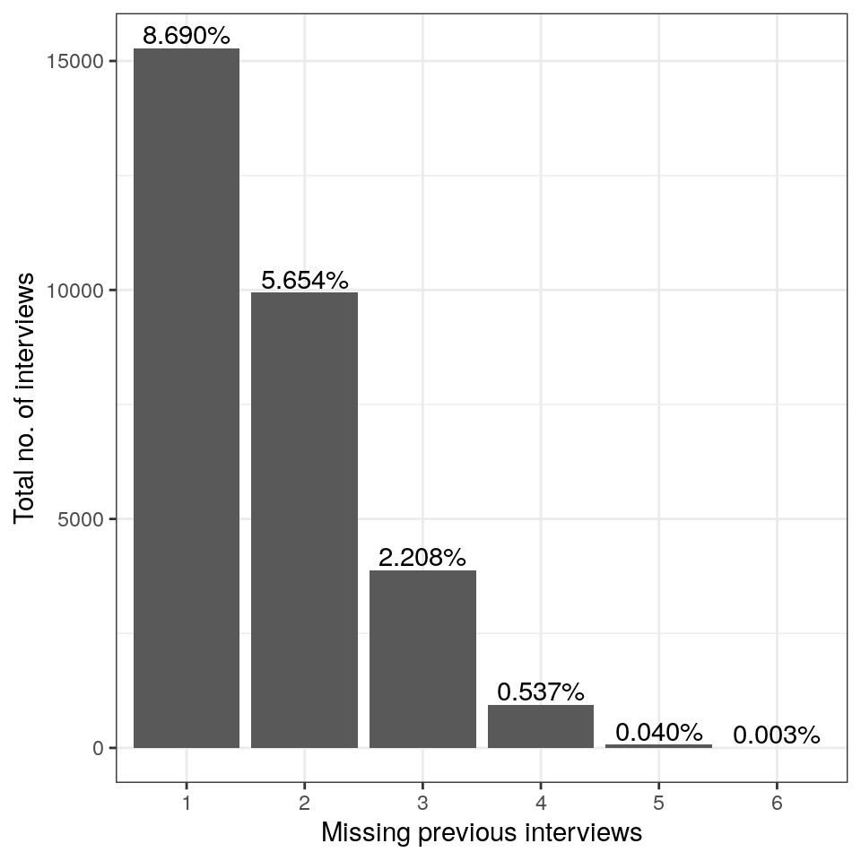

## Distribution of services

- The Figure below shows the proportion of households with improved services over years. The dotted lines represent the household average for each service over the entire study period.

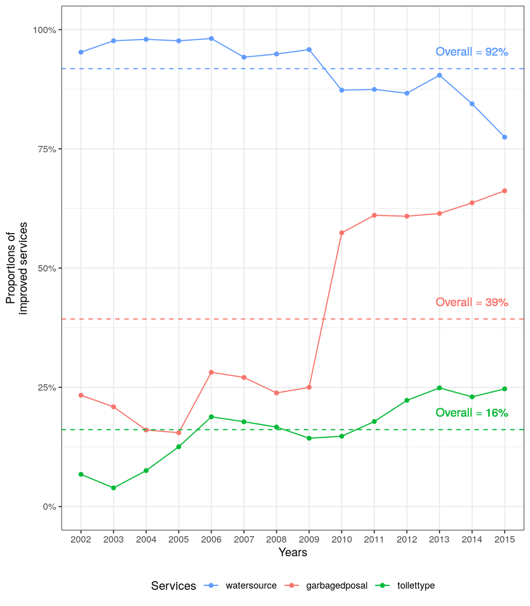

### No. of interviews completed by HH

- If every household was interviewed per year, we would expect $14$ interviews per household. On the contrary, over $40\%$ of the households only had $1$ interview over the entire study period.
- Denominator is number of HH (expected number of interviews per year)

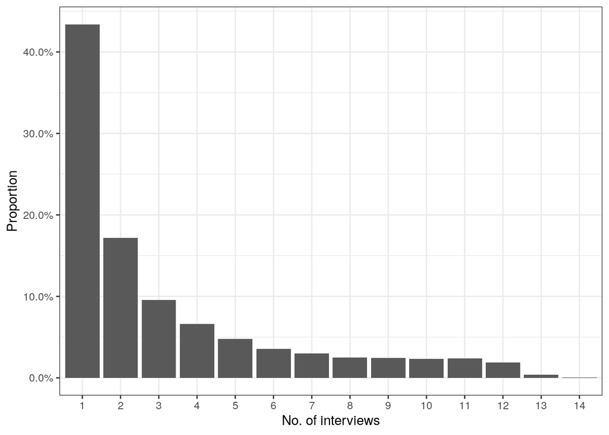

### No. of interviews per year

- The Figure below shows the percentage of interviews per year.
  - We may need to seek for clarification on low percentage in $2003$

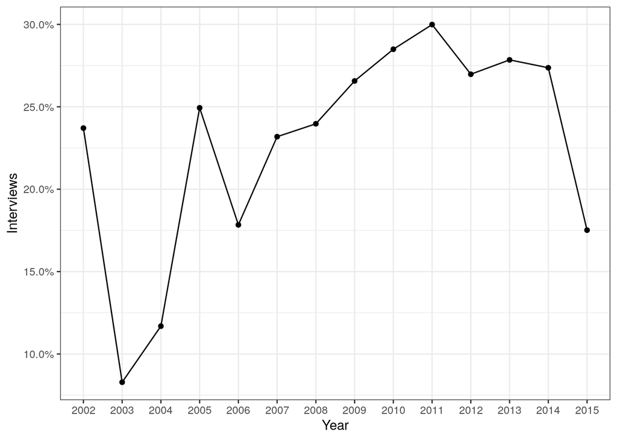

### Current vs previous year service status (JD: Status Quo?)

- We track service transitions from the previous year to the current year (within households):
  - **All -**: Service not improved both in the previous and in the current year
  - **All +**: Improved service both in the previous and current year
  - **No prev.**: Had no service in the previous year (missing interview in the previous year)
  - **Gain**: Unimproved service in the previous year but improved service in the current year
  - **Loss**: Improved service in the previous year but unimproved service in the current year

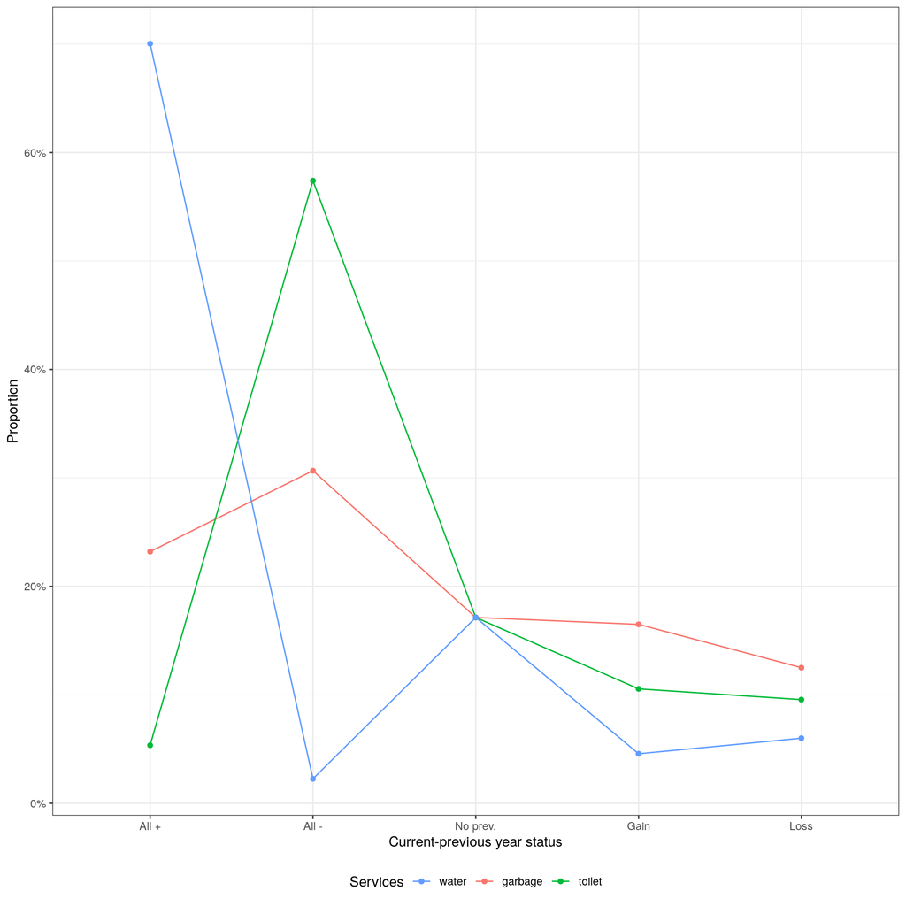

### Household size scaling

- I wasn’t sure why I still hard large value after scaling.
- Do we need to scale household size?
- Should we think of back transforming the predictor effects from effect plots? Is this something sensible?

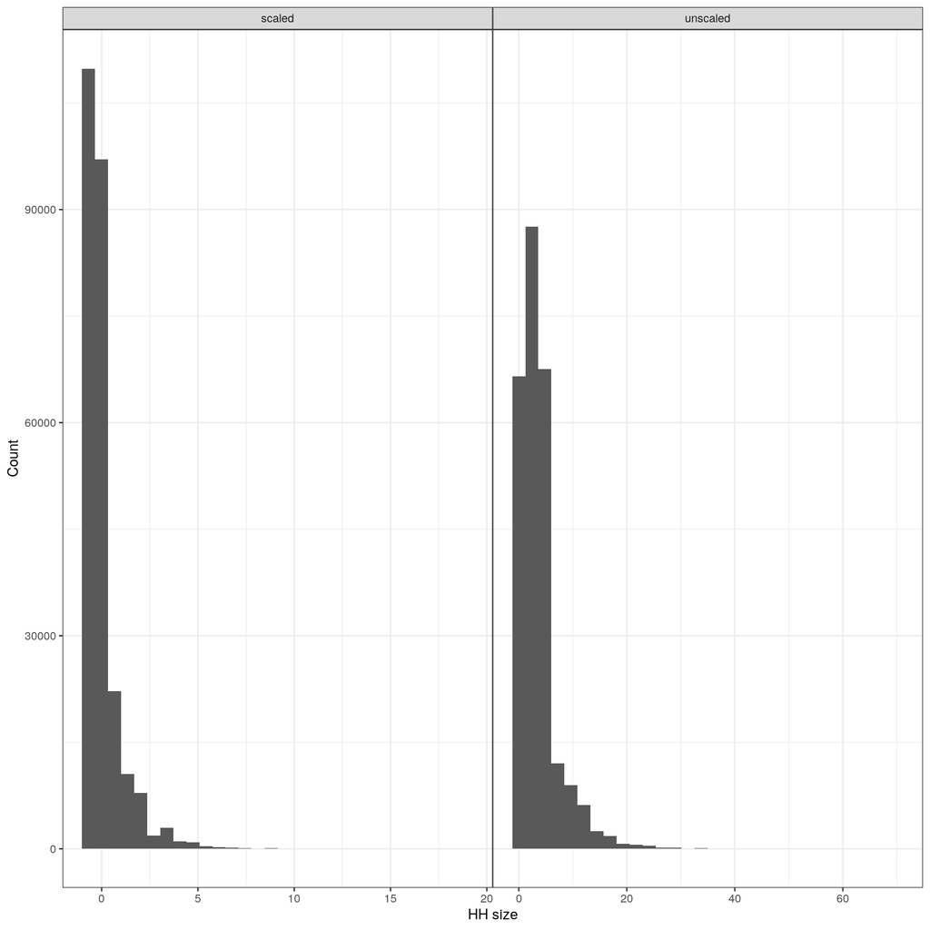

## Variables

Distribution of missing cases per variable is shown in the table below

- A total of 256358 were done between $2002 - 2015$.
- There are 80521 households, each interviewed once for every interview year
- Not all households had interviews conducted every year
- Although `hungerscale` and `belowpovertyline` have more proportion of missing cases, `wealthindex` is considered a good proxy for the two.

| variable | miss_count | miss_prop |
| --- | --- | --- |
| hungerscale | 55436 | 21.6 |
| belowpovertyline | 55256 | 21.6 |
| hhsize | 929 | 0.4 |
| hhsize_unscaled | 929 | 0.4 |
| ethnicity | 673 | 0.3 |
| watersource | 0 | 0 |
| toilettype | 0 | 0 |
| garbagedposal | 0 | 0 |
| age | 0 | 0 |
| gender | 0 | 0 |

[output cut: 5 more lines]

**Improved**

**Unimproved**

- **Drinking water source**
- Piped water into dwelling, plot or yard
- Public tap/standpipe
- Tube well / borehole
- Protected dug well with hand pump
- Protected spring
- Rainwater collection from the roof
- Unprotected dug well
- Unprotected spring
- Small water vendor (cart with small tank or drum)
- Bottled water
- Tanker truck
- Rainwater collection from surface run off. Surface water (river, dam, lake, pond, stream, canal, irrigation channels)
- Protected dug well with bucket
- **Toilet facility type**
- Flush / pour flush to piped sewer system or septic tank or pit latrine
- VIP latrine
- Pit latrine with slab
- Composting toilet
- Flush / pour flush to elsewhere e.g. to open drain
- Pit latrine without slab (slab with holes) /open pit
- Bucket
- Hanging toilet / hanging latrine
- No facilities or bush or field
- **Garbage disposal method**
- Garbage dump
- Private pits
- Public pits
- Proper garbage disposal services
- Other organized groups such as the national youth service
- In the river
- On the road, railway line/station
- In drainage/sewage/ trench
- Vacant/abandoned house/plot/field
- No designated place/all over
- Street boys/urchins
- Burning
- Other

## Models

- Fit two separate models
  - First (household specific) year model
  - Previous year model without first year data

**Year 1 model**

- We only have a single observation per HH. I feel we don’t need a hh level random effect

## Results

### Year 1 model

#### Estimated effect sizes

- This refers to household specific first observational year

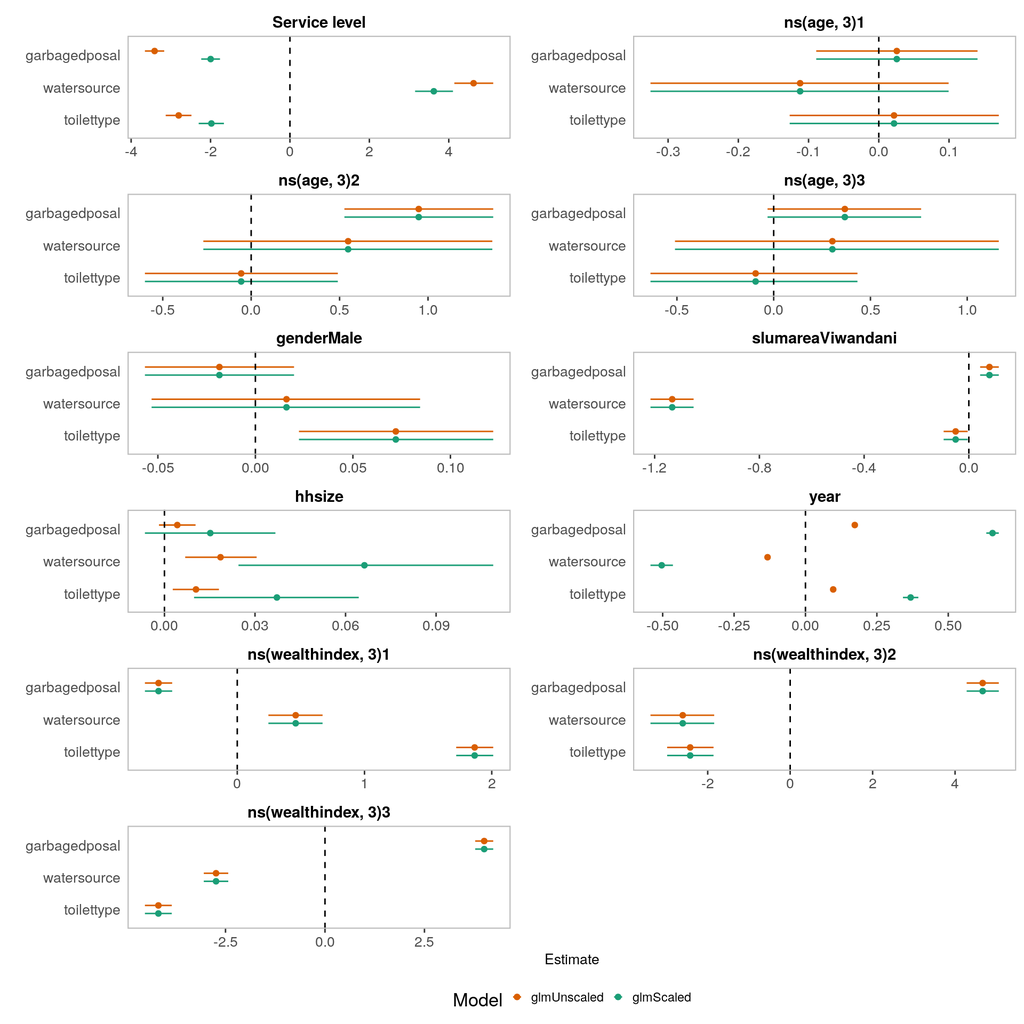

#### Predicted effects

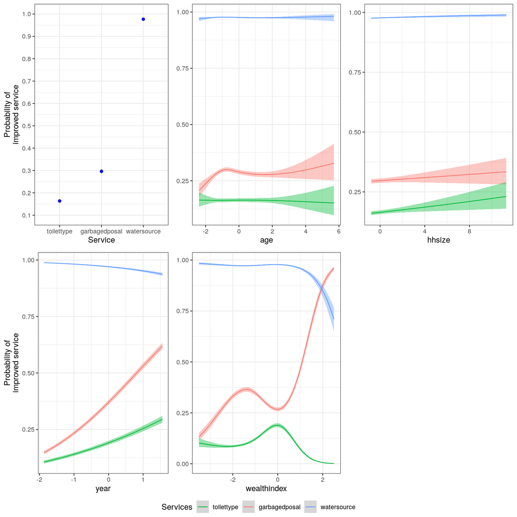

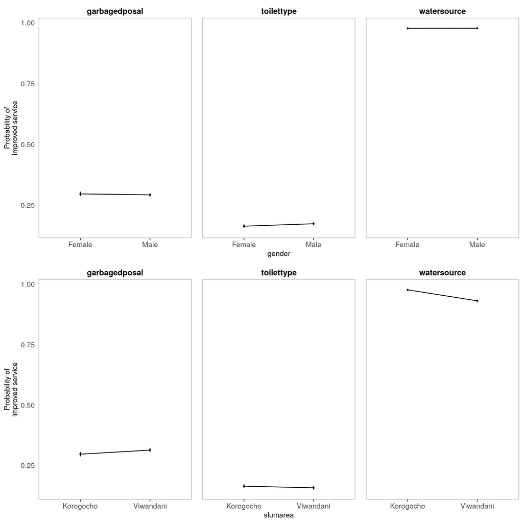

### Previous year model

#### Estimated effect sizes

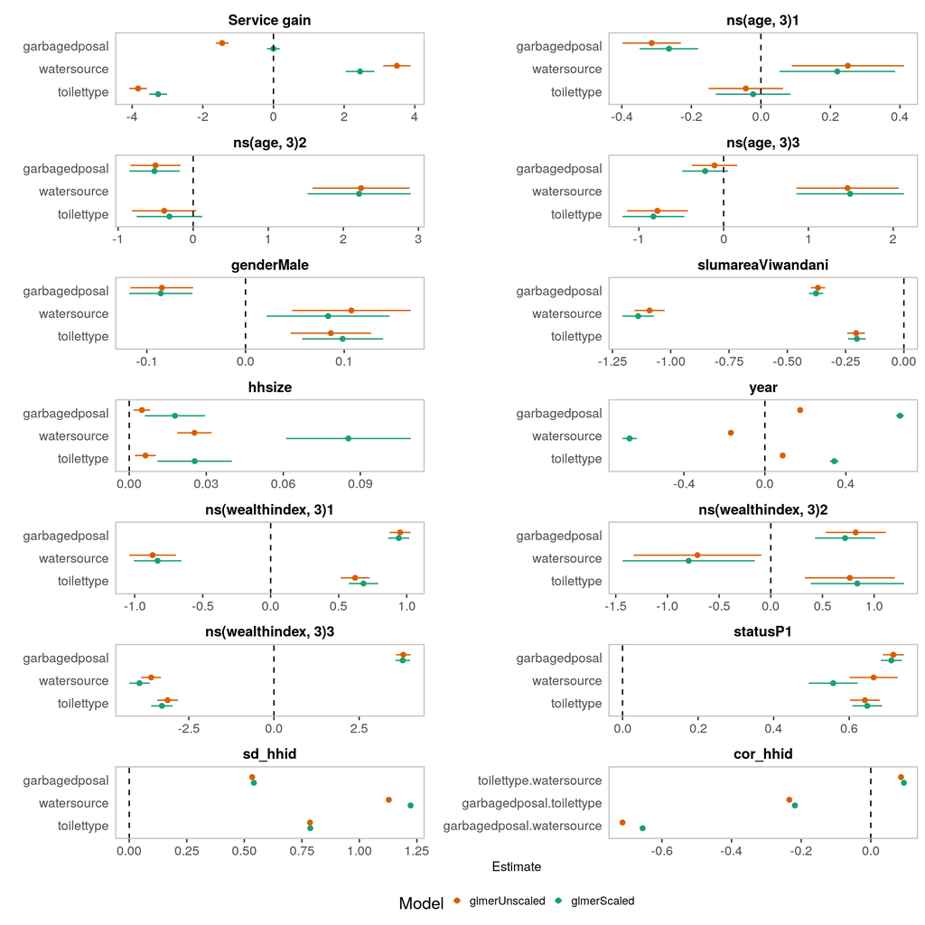

#### Predicted effects

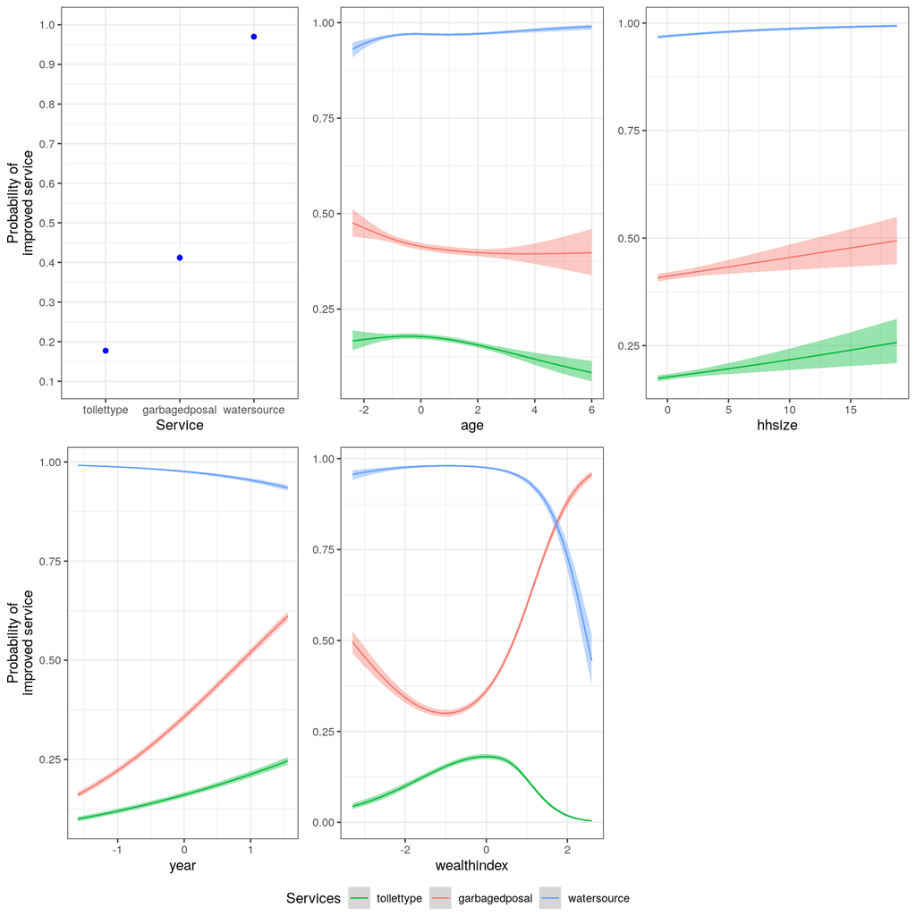

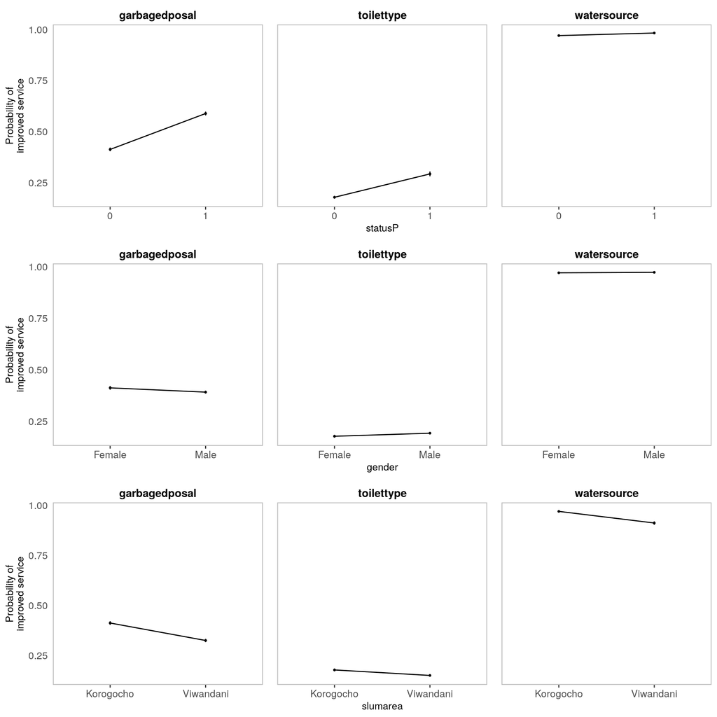